# Risk Factor Analysis

## Outcome Variable

**Outcome Variable:** wasted

## Predictor Variables

**Intervention Variable:** gagebrth

**Adjustment Set:**

- arm
- sex
- W_mage
- meducyrs
- feducyrs
- hhwealth_quart
- W_nrooms
- W_nchldlt5
- brthmon
- W_parity
- impfloor
- impsan
- safeh20
- delta_W_mage
- delta_meducyrs
- delta_feducyrs
- delta_hhwealth_quart
- delta_W_nrooms
- delta_W_nchldlt5
- delta_brthmon
- delta_W_parity
- delta_impfloor
- delta_impsan
- delta_safeh20

## Stratifying Variables

The analysis was stratified on these variable(s):

- agecat
- studyid
- country

## Data Summary

| agecat | studyid | country | gagebrth | wasted | n_cell | n |
| --- | --- | --- | --- | --- | --- | --- |
| Birth | ki1000108-CMC-V-BCS-2002 | INDIA | Full or late term | 0 | 46 | 87 |
| Birth | ki1000108-CMC-V-BCS-2002 | INDIA | Full or late term | 1 | 8 | 87 |
| Birth | ki1000108-CMC-V-BCS-2002 | INDIA | Preterm | 0 | 8 | 87 |
| Birth | ki1000108-CMC-V-BCS-2002 | INDIA | Preterm | 1 | 2 | 87 |
| Birth | ki1000108-CMC-V-BCS-2002 | INDIA | Early term | 0 | 20 | 87 |
| Birth | ki1000108-CMC-V-BCS-2002 | INDIA | Early term | 1 | 3 | 87 |
| Birth | ki1000108-IRC | INDIA | Full or late term | 0 | 164 | 328 |
| Birth | ki1000108-IRC | INDIA | Full or late term | 1 | 49 | 328 |
| Birth | ki1000108-IRC | INDIA | Preterm | 0 | 19 | 328 |
| Birth | ki1000108-IRC | INDIA | Preterm | 1 | 13 | 328 |
| Birth | ki1000108-IRC | INDIA | Early term | 0 | 58 | 328 |
| Birth | ki1000108-IRC | INDIA | Early term | 1 | 25 | 328 |
| Birth | ki1000109-EE | PAKISTAN | Full or late term | 0 | 0 | 2 |
| Birth | ki1000109-EE | PAKISTAN | Full or late term | 1 | 0 | 2 |
| Birth | ki1000109-EE | PAKISTAN | Preterm | 0 | 2 | 2 |
| Birth | ki1000109-EE | PAKISTAN | Preterm | 1 | 0 | 2 |
| Birth | ki1000109-EE | PAKISTAN | Early term | 0 | 0 | 2 |
| Birth | ki1000109-EE | PAKISTAN | Early term | 1 | 0 | 2 |
| Birth | ki1000304b-SAS-CompFeed | INDIA | Full or late term | 0 | 1 | 166 |
| Birth | ki1000304b-SAS-CompFeed | INDIA | Full or late term | 1 | 0 | 166 |
| Birth | ki1000304b-SAS-CompFeed | INDIA | Preterm | 0 | 141 | 166 |
| Birth | ki1000304b-SAS-CompFeed | INDIA | Preterm | 1 | 10 | 166 |
| Birth | ki1000304b-SAS-CompFeed | INDIA | Early term | 0 | 13 | 166 |
| Birth | ki1000304b-SAS-CompFeed | INDIA | Early term | 1 | 1 | 166 |
| Birth | ki1017093c-NIH-Crypto | BANGLADESH | Full or late term | 0 | 5 | 23 |
| Birth | ki1017093c-NIH-Crypto | BANGLADESH | Full or late term | 1 | 1 | 23 |
| Birth | ki1017093c-NIH-Crypto | BANGLADESH | Preterm | 0 | 2 | 23 |
| Birth | ki1017093c-NIH-Crypto | BANGLADESH | Preterm | 1 | 1 | 23 |
| Birth | ki1017093c-NIH-Crypto | BANGLADESH | Early term | 0 | 13 | 23 |
| Birth | ki1017093c-NIH-Crypto | BANGLADESH | Early term | 1 | 1 | 23 |

[output cut: 168 more lines]

The following strata were considered:

- agecat: 24 months, studyid: ki1000108-CMC-V-BCS-2002, country: INDIA
- agecat: 24 months, studyid: ki1000108-IRC, country: INDIA
- agecat: 24 months, studyid: ki1017093c-NIH-Crypto, country: BANGLADESH
- agecat: 24 months, studyid: ki1066203-TanzaniaChild2, country: TANZANIA, UNITED REPUBLIC OF
- agecat: 24 months, studyid: ki1101329-Keneba, country: GAMBIA
- agecat: 24 months, studyid: ki1119695-PROBIT, country: BELARUS
- agecat: 24 months, studyid: ki1135781-COHORTS, country: GUATEMALA
- agecat: 24 months, studyid: ki1135781-COHORTS, country: INDIA
- agecat: 24 months, studyid: ki1135781-COHORTS, country: PHILIPPINES
- agecat: 24 months, studyid: kiGH5241-JiVitA-3, country: BANGLADESH
- agecat: 6 months, studyid: ki1000108-CMC-V-BCS-2002, country: INDIA
- agecat: 6 months, studyid: ki1000108-IRC, country: INDIA
- agecat: 6 months, studyid: ki1000109-EE, country: PAKISTAN
- agecat: 6 months, studyid: ki1000304b-SAS-CompFeed, country: INDIA
- agecat: 6 months, studyid: ki1017093c-NIH-Crypto, country: BANGLADESH
- agecat: 6 months, studyid: ki1066203-TanzaniaChild2, country: TANZANIA, UNITED REPUBLIC OF
- agecat: 6 months, studyid: ki1101329-Keneba, country: GAMBIA
- agecat: 6 months, studyid: ki1119695-PROBIT, country: BELARUS
- agecat: 6 months, studyid: ki1135781-COHORTS, country: GUATEMALA
- agecat: 6 months, studyid: ki1135781-COHORTS, country: INDIA
- agecat: 6 months, studyid: ki1135781-COHORTS, country: PHILIPPINES
- agecat: 6 months, studyid: kiGH5241-JiVitA-3, country: BANGLADESH
- agecat: Birth, studyid: ki1000108-CMC-V-BCS-2002, country: INDIA
- agecat: Birth, studyid: ki1000108-IRC, country: INDIA
- agecat: Birth, studyid: ki1000109-EE, country: PAKISTAN
- agecat: Birth, studyid: ki1000304b-SAS-CompFeed, country: INDIA
- agecat: Birth, studyid: ki1017093c-NIH-Crypto, country: BANGLADESH
- agecat: Birth, studyid: ki1101329-Keneba, country: GAMBIA
- agecat: Birth, studyid: ki1119695-PROBIT, country: BELARUS
- agecat: Birth, studyid: ki1135781-COHORTS, country: GUATEMALA
- agecat: Birth, studyid: ki1135781-COHORTS, country: INDIA
- agecat: Birth, studyid: ki1135781-COHORTS, country: PHILIPPINES
- agecat: Birth, studyid: kiGH5241-JiVitA-3, country: BANGLADESH

### Dropped Strata

Some strata were dropped due to rare outcomes:

- agecat: Birth, studyid: ki1000108-CMC-V-BCS-2002, country: INDIA
- agecat: Birth, studyid: ki1000109-EE, country: PAKISTAN
- agecat: Birth, studyid: ki1000304b-SAS-CompFeed, country: INDIA
- agecat: Birth, studyid: ki1017093c-NIH-Crypto, country: BANGLADESH
- agecat: 6 months, studyid: ki1000109-EE, country: PAKISTAN
- agecat: 6 months, studyid: ki1017093c-NIH-Crypto, country: BANGLADESH
- agecat: 6 months, studyid: ki1135781-COHORTS, country: GUATEMALA
- agecat: 24 months, studyid: ki1000108-CMC-V-BCS-2002, country: INDIA
- agecat: 24 months, studyid: ki1017093c-NIH-Crypto, country: BANGLADESH
- agecat: 24 months, studyid: ki1066203-TanzaniaChild2, country: TANZANIA, UNITED REPUBLIC OF
- agecat: 24 months, studyid: ki1119695-PROBIT, country: BELARUS

## Methods Detail

We’re interested in the causal parameters $E[Y_a]$ for all values of $a \in \mathcal{A}$. These parameters represent the mean outcome if, possibly contrary to fact, we intervened to set all units to have $A=a$. Under the randomization and positivity assumptions, these are identified by the statistical parameters $\psi_a=E_W[E_{Y|A,W}(Y|A=a,W)]$. In addition, we’re interested in the mean of $Y$, $E[Y]$ under no intervention (the observed mean). We will estimate these parameters by using SuperLearner to fit the relevant likelihood factors – $E_{Y|A,W}(Y|A=a,W)$ and $p(A=a|W)$, and then updating our likelihood fit using a joint TMLE.

For unadjusted analyses ($W=\{\}$), initial likelihoods were estimated using Lrnr_glm to estimate the simple $E(Y|A)$ and Lrnr_mean to estimate $p(A)$. For adjusted analyses, a small library containing Lrnr_glmnet, Lrnr_xgboost, and Lrnr_mean was used.

Having estimated these parameters, we will then use the delta method to estimate relative risks and attributable risks relative to a prespecified baseline level of $A$.

# Results Detail

## Results Plots

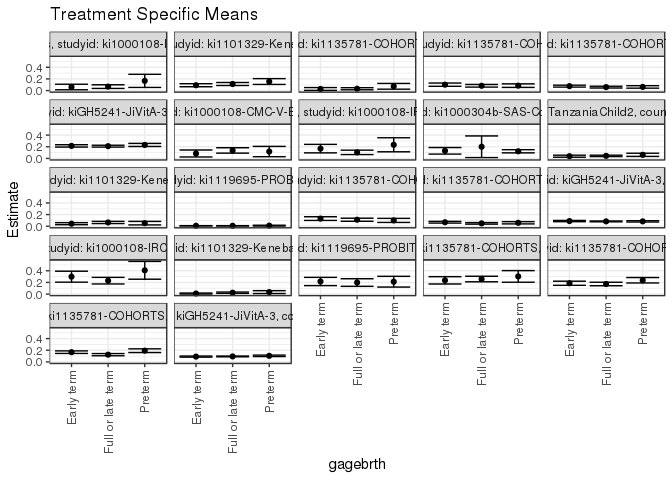

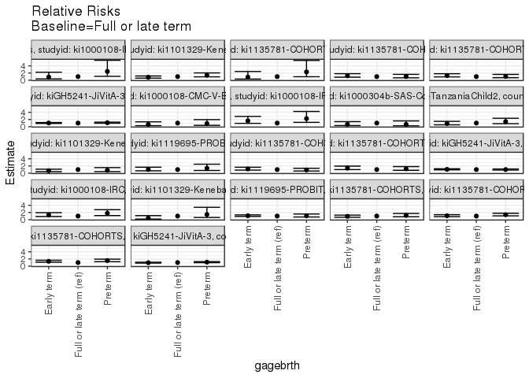

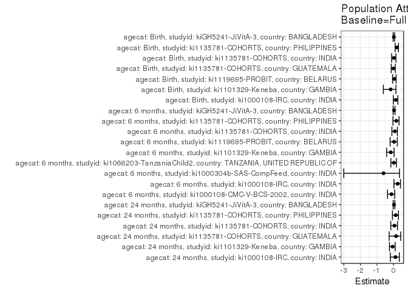

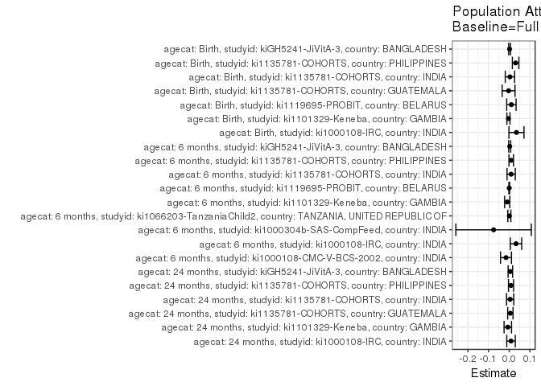

## Results Table

### Parameter: TSM

| agecat | studyid | country | intervention_level | baseline_level | estimate | ci_lower | ci_upper |
| --- | --- | --- | --- | --- | --- | --- | --- |
| Birth | ki1000108-IRC | INDIA | Full or late term | NA | 0.2300153 | 0.1736607 | 0.2863699 |
| Birth | ki1000108-IRC | INDIA | Preterm | NA | 0.4076452 | 0.2552650 | 0.5600254 |
| Birth | ki1000108-IRC | INDIA | Early term | NA | 0.2983663 | 0.2042109 | 0.3925218 |
| Birth | ki1101329-Keneba | GAMBIA | Full or late term | NA | 0.0235294 | 0.0121326 | 0.0349262 |
| Birth | ki1101329-Keneba | GAMBIA | Preterm | NA | 0.0338164 | 0.0091837 | 0.0584491 |
| Birth | ki1101329-Keneba | GAMBIA | Early term | NA | 0.0097276 | 0.0012397 | 0.0182156 |
| Birth | ki1119695-PROBIT | BELARUS | Full or late term | NA | 0.1981661 | 0.1329775 | 0.2633547 |
| Birth | ki1119695-PROBIT | BELARUS | Preterm | NA | 0.2123588 | 0.1202026 | 0.3045150 |
| Birth | ki1119695-PROBIT | BELARUS | Early term | NA | 0.2162465 | 0.1455854 | 0.2869077 |
| Birth | ki1135781-COHORTS | GUATEMALA | Full or late term | NA | 0.2580811 | 0.2106008 | 0.3055614 |
| Birth | ki1135781-COHORTS | GUATEMALA | Preterm | NA | 0.3030170 | 0.2032629 | 0.4027711 |
| Birth | ki1135781-COHORTS | GUATEMALA | Early term | NA | 0.2357157 | 0.1726911 | 0.2987404 |
| Birth | ki1135781-COHORTS | INDIA | Full or late term | NA | 0.1729311 | 0.1429461 | 0.2029161 |
| Birth | ki1135781-COHORTS | INDIA | Preterm | NA | 0.2373390 | 0.1909007 | 0.2837774 |
| Birth | ki1135781-COHORTS | INDIA | Early term | NA | 0.1857674 | 0.1508117 | 0.2207232 |
| Birth | ki1135781-COHORTS | PHILIPPINES | Full or late term | NA | 0.1243469 | 0.1053642 | 0.1433296 |
| Birth | ki1135781-COHORTS | PHILIPPINES | Preterm | NA | 0.1926543 | 0.1606551 | 0.2246534 |
| Birth | ki1135781-COHORTS | PHILIPPINES | Early term | NA | 0.1669744 | 0.1454403 | 0.1885085 |
| Birth | kiGH5241-JiVitA-3 | BANGLADESH | Full or late term | NA | 0.0942216 | 0.0874704 | 0.1009727 |
| Birth | kiGH5241-JiVitA-3 | BANGLADESH | Preterm | NA | 0.1043733 | 0.0921376 | 0.1166090 |
| Birth | kiGH5241-JiVitA-3 | BANGLADESH | Early term | NA | 0.0907100 | 0.0813578 | 0.1000622 |
| 6 months | ki1000108-CMC-V-BCS-2002 | INDIA | Full or late term | NA | 0.1367925 | 0.0904694 | 0.1831155 |
| 6 months | ki1000108-CMC-V-BCS-2002 | INDIA | Preterm | NA | 0.1176471 | 0.0290941 | 0.2062000 |
| 6 months | ki1000108-CMC-V-BCS-2002 | INDIA | Early term | NA | 0.0843373 | 0.0244665 | 0.1442082 |
| 6 months | ki1000108-IRC | INDIA | Full or late term | NA | 0.1034017 | 0.0656887 | 0.1411147 |
| 6 months | ki1000108-IRC | INDIA | Preterm | NA | 0.2336043 | 0.1133819 | 0.3538268 |
| 6 months | ki1000108-IRC | INDIA | Early term | NA | 0.1677754 | 0.0949969 | 0.2405538 |
| 6 months | ki1000304b-SAS-CompFeed | INDIA | Full or late term | NA | 0.2000000 | 0.0143199 | 0.3856801 |
| 6 months | ki1000304b-SAS-CompFeed | INDIA | Preterm | NA | 0.1225166 | 0.0952376 | 0.1497956 |
| 6 months | ki1000304b-SAS-CompFeed | INDIA | Early term | NA | 0.1304348 | 0.0742562 | 0.1866133 |
| 6 months | ki1066203-TanzaniaChild2 | TANZANIA, UNITED REPUBLIC OF | Full or late term | NA | 0.0438733 | 0.0321327 | 0.0556140 |
| 6 months | ki1066203-TanzaniaChild2 | TANZANIA, UNITED REPUBLIC OF | Preterm | NA | 0.0615641 | 0.0345884 | 0.0885397 |
| 6 months | ki1066203-TanzaniaChild2 | TANZANIA, UNITED REPUBLIC OF | Early term | NA | 0.0382697 | 0.0207562 | 0.0557831 |
| 6 months | ki1101329-Keneba | GAMBIA | Full or late term | NA | 0.0647906 | 0.0459789 | 0.0836023 |
| 6 months | ki1101329-Keneba | GAMBIA | Preterm | NA | 0.0528997 | 0.0226683 | 0.0831310 |
| 6 months | ki1101329-Keneba | GAMBIA | Early term | NA | 0.0438025 | 0.0261517 | 0.0614534 |
| 6 months | ki1119695-PROBIT | BELARUS | Full or late term | NA | 0.0079950 | 0.0052987 | 0.0106913 |
| 6 months | ki1119695-PROBIT | BELARUS | Preterm | NA | 0.0108893 | 0.0041768 | 0.0176017 |
| 6 months | ki1119695-PROBIT | BELARUS | Early term | NA | 0.0083322 | 0.0061258 | 0.0105385 |
| 6 months | ki1135781-COHORTS | INDIA | Full or late term | NA | 0.1116182 | 0.0853676 | 0.1378688 |
| 6 months | ki1135781-COHORTS | INDIA | Preterm | NA | 0.1001909 | 0.0653006 | 0.1350811 |
| 6 months | ki1135781-COHORTS | INDIA | Early term | NA | 0.1313392 | 0.0997135 | 0.1629649 |
| 6 months | ki1135781-COHORTS | PHILIPPINES | Full or late term | NA | 0.0493625 | 0.0361232 | 0.0626019 |
| 6 months | ki1135781-COHORTS | PHILIPPINES | Preterm | NA | 0.0594603 | 0.0402443 | 0.0786764 |
| 6 months | ki1135781-COHORTS | PHILIPPINES | Early term | NA | 0.0687256 | 0.0537880 | 0.0836633 |
| 6 months | kiGH5241-JiVitA-3 | BANGLADESH | Full or late term | NA | 0.0835034 | 0.0763914 | 0.0906153 |
| 6 months | kiGH5241-JiVitA-3 | BANGLADESH | Preterm | NA | 0.0838179 | 0.0725554 | 0.0950803 |
| 6 months | kiGH5241-JiVitA-3 | BANGLADESH | Early term | NA | 0.0885643 | 0.0782075 | 0.0989212 |
| 24 months | ki1000108-IRC | INDIA | Full or late term | NA | 0.0680000 | 0.0367537 | 0.0992463 |
| 24 months | ki1000108-IRC | INDIA | Preterm | NA | 0.1666667 | 0.0538133 | 0.2795201 |
| 24 months | ki1000108-IRC | INDIA | Early term | NA | 0.0612245 | 0.0136980 | 0.1087510 |
| 24 months | ki1101329-Keneba | GAMBIA | Full or late term | NA | 0.1129552 | 0.0871777 | 0.1387327 |
| 24 months | ki1101329-Keneba | GAMBIA | Preterm | NA | 0.1552234 | 0.1056147 | 0.2048322 |
| 24 months | ki1101329-Keneba | GAMBIA | Early term | NA | 0.0920882 | 0.0658430 | 0.1183334 |
| 24 months | ki1135781-COHORTS | GUATEMALA | Full or late term | NA | 0.0318302 | 0.0140966 | 0.0495639 |
| 24 months | ki1135781-COHORTS | GUATEMALA | Preterm | NA | 0.0733945 | 0.0244008 | 0.1223881 |
| 24 months | ki1135781-COHORTS | GUATEMALA | Early term | NA | 0.0276243 | 0.0037298 | 0.0515188 |
| 24 months | ki1135781-COHORTS | INDIA | Full or late term | NA | 0.0823387 | 0.0596075 | 0.1050700 |
| 24 months | ki1135781-COHORTS | INDIA | Preterm | NA | 0.0848775 | 0.0545478 | 0.1152071 |
| 24 months | ki1135781-COHORTS | INDIA | Early term | NA | 0.1013865 | 0.0736000 | 0.1291730 |
| 24 months | ki1135781-COHORTS | PHILIPPINES | Full or late term | NA | 0.0594388 | 0.0441677 | 0.0747100 |
| 24 months | ki1135781-COHORTS | PHILIPPINES | Preterm | NA | 0.0627920 | 0.0414987 | 0.0840853 |
| 24 months | ki1135781-COHORTS | PHILIPPINES | Early term | NA | 0.0762616 | 0.0594970 | 0.0930261 |
| 24 months | kiGH5241-JiVitA-3 | BANGLADESH | Full or late term | NA | 0.2101006 | 0.1939497 | 0.2262515 |
| 24 months | kiGH5241-JiVitA-3 | BANGLADESH | Preterm | NA | 0.2311181 | 0.2048033 | 0.2574330 |
| 24 months | kiGH5241-JiVitA-3 | BANGLADESH | Early term | NA | 0.2144932 | 0.1945127 | 0.2344737 |

### Parameter: E(Y)

| agecat | studyid | country | intervention_level | baseline_level | estimate | ci_lower | ci_upper |
| --- | --- | --- | --- | --- | --- | --- | --- |
| Birth | ki1000108-IRC | INDIA | NA | NA | 0.2652439 | 0.2173954 | 0.3130924 |
| Birth | ki1101329-Keneba | GAMBIA | NA | NA | 0.0199857 | 0.0126548 | 0.0273167 |
| Birth | ki1119695-PROBIT | BELARUS | NA | NA | 0.2089120 | 0.1435514 | 0.2742726 |
| Birth | ki1135781-COHORTS | GUATEMALA | NA | NA | 0.2552448 | 0.2194833 | 0.2910062 |
| Birth | ki1135781-COHORTS | INDIA | NA | NA | 0.1765663 | 0.1552399 | 0.1978927 |
| Birth | ki1135781-COHORTS | PHILIPPINES | NA | NA | 0.1555324 | 0.1422803 | 0.1687844 |
| Birth | kiGH5241-JiVitA-3 | BANGLADESH | NA | NA | 0.0961020 | 0.0908277 | 0.1013762 |
| 6 months | ki1000108-CMC-V-BCS-2002 | INDIA | NA | NA | 0.1213873 | 0.0869266 | 0.1558480 |
| 6 months | ki1000108-IRC | INDIA | NA | NA | 0.1365979 | 0.1023826 | 0.1708133 |
| 6 months | ki1000304b-SAS-CompFeed | INDIA | NA | NA | 0.1245283 | 0.0993306 | 0.1497260 |
| 6 months | ki1066203-TanzaniaChild2 | TANZANIA, UNITED REPUBLIC OF | NA | NA | 0.0446898 | 0.0354016 | 0.0539780 |
| 6 months | ki1101329-Keneba | GAMBIA | NA | NA | 0.0553130 | 0.0432217 | 0.0674042 |
| 6 months | ki1119695-PROBIT | BELARUS | NA | NA | 0.0082503 | 0.0066012 | 0.0098994 |
| 6 months | ki1135781-COHORTS | INDIA | NA | NA | 0.1211890 | 0.1035235 | 0.1388545 |
| 6 months | ki1135781-COHORTS | PHILIPPINES | NA | NA | 0.0592179 | 0.0502884 | 0.0681474 |
| 6 months | kiGH5241-JiVitA-3 | BANGLADESH | NA | NA | 0.0860948 | 0.0805860 | 0.0916037 |
| 24 months | ki1000108-IRC | INDIA | NA | NA | 0.0769231 | 0.0504429 | 0.1034032 |
| 24 months | ki1101329-Keneba | GAMBIA | NA | NA | 0.1063094 | 0.0885410 | 0.1240778 |
| 24 months | ki1135781-COHORTS | GUATEMALA | NA | NA | 0.0374813 | 0.0230560 | 0.0519065 |
| 24 months | ki1135781-COHORTS | INDIA | NA | NA | 0.0870570 | 0.0717143 | 0.1023997 |
| 24 months | ki1135781-COHORTS | PHILIPPINES | NA | NA | 0.0683690 | 0.0583283 | 0.0784097 |
| 24 months | kiGH5241-JiVitA-3 | BANGLADESH | NA | NA | 0.2158924 | 0.2043232 | 0.2274616 |

### Parameter: RR

| agecat | studyid | country | intervention_level | baseline_level | estimate | ci_lower | ci_upper |
| --- | --- | --- | --- | --- | --- | --- | --- |
| Birth | ki1000108-IRC | INDIA | Full or late term | Full or late term | 1.0000000 | 1.0000000 | 1.000000 |
| Birth | ki1000108-IRC | INDIA | Preterm | Full or late term | 1.7722525 | 1.1335201 | 2.770907 |
| Birth | ki1000108-IRC | INDIA | Early term | Full or late term | 1.2971587 | 0.8702783 | 1.933428 |
| Birth | ki1101329-Keneba | GAMBIA | Full or late term | Full or late term | 1.0000000 | 1.0000000 | 1.000000 |
| Birth | ki1101329-Keneba | GAMBIA | Preterm | Full or late term | 1.4371981 | 0.5992553 | 3.446842 |
| Birth | ki1101329-Keneba | GAMBIA | Early term | Full or late term | 0.4134241 | 0.1523972 | 1.121539 |
| Birth | ki1119695-PROBIT | BELARUS | Full or late term | Full or late term | 1.0000000 | 1.0000000 | 1.000000 |
| Birth | ki1119695-PROBIT | BELARUS | Preterm | Full or late term | 1.0716203 | 0.7330488 | 1.566567 |
| Birth | ki1119695-PROBIT | BELARUS | Early term | Full or late term | 1.0912390 | 0.8904494 | 1.337305 |
| Birth | ki1135781-COHORTS | GUATEMALA | Full or late term | Full or late term | 1.0000000 | 1.0000000 | 1.000000 |
| Birth | ki1135781-COHORTS | GUATEMALA | Preterm | Full or late term | 1.1741153 | 0.8055331 | 1.711347 |
| Birth | ki1135781-COHORTS | GUATEMALA | Early term | Full or late term | 0.9133397 | 0.6604241 | 1.263112 |
| Birth | ki1135781-COHORTS | INDIA | Full or late term | Full or late term | 1.0000000 | 1.0000000 | 1.000000 |
| Birth | ki1135781-COHORTS | INDIA | Preterm | Full or late term | 1.3724483 | 1.0579817 | 1.780385 |
| Birth | ki1135781-COHORTS | INDIA | Early term | Full or late term | 1.0742280 | 0.8325957 | 1.385986 |
| Birth | ki1135781-COHORTS | PHILIPPINES | Full or late term | Full or late term | 1.0000000 | 1.0000000 | 1.000000 |
| Birth | ki1135781-COHORTS | PHILIPPINES | Preterm | Full or late term | 1.5493292 | 1.2370303 | 1.940470 |
| Birth | ki1135781-COHORTS | PHILIPPINES | Early term | Full or late term | 1.3428112 | 1.1000756 | 1.639107 |
| Birth | kiGH5241-JiVitA-3 | BANGLADESH | Full or late term | Full or late term | 1.0000000 | 1.0000000 | 1.000000 |
| Birth | kiGH5241-JiVitA-3 | BANGLADESH | Preterm | Full or late term | 1.1077430 | 0.9670656 | 1.268885 |
| Birth | kiGH5241-JiVitA-3 | BANGLADESH | Early term | Full or late term | 0.9627310 | 0.8508260 | 1.089354 |
| 6 months | ki1000108-CMC-V-BCS-2002 | INDIA | Full or late term | Full or late term | 1.0000000 | 1.0000000 | 1.000000 |
| 6 months | ki1000108-CMC-V-BCS-2002 | INDIA | Preterm | Full or late term | 0.8600406 | 0.3767610 | 1.963234 |
| 6 months | ki1000108-CMC-V-BCS-2002 | INDIA | Early term | Full or late term | 0.6165351 | 0.2807839 | 1.353765 |
| 6 months | ki1000108-IRC | INDIA | Full or late term | Full or late term | 1.0000000 | 1.0000000 | 1.000000 |
| 6 months | ki1000108-IRC | INDIA | Preterm | Full or late term | 2.2591925 | 1.2023445 | 4.244999 |
| 6 months | ki1000108-IRC | INDIA | Early term | Full or late term | 1.6225593 | 0.9206531 | 2.859599 |
| 6 months | ki1000304b-SAS-CompFeed | INDIA | Full or late term | Full or late term | 1.0000000 | 1.0000000 | 1.000000 |
| 6 months | ki1000304b-SAS-CompFeed | INDIA | Preterm | Full or late term | 0.6125828 | 0.2337629 | 1.605292 |
| 6 months | ki1000304b-SAS-CompFeed | INDIA | Early term | Full or late term | 0.6521739 | 0.3031919 | 1.402843 |
| 6 months | ki1066203-TanzaniaChild2 | TANZANIA, UNITED REPUBLIC OF | Full or late term | Full or late term | 1.0000000 | 1.0000000 | 1.000000 |
| 6 months | ki1066203-TanzaniaChild2 | TANZANIA, UNITED REPUBLIC OF | Preterm | Full or late term | 1.4032234 | 0.8398015 | 2.344644 |
| 6 months | ki1066203-TanzaniaChild2 | TANZANIA, UNITED REPUBLIC OF | Early term | Full or late term | 0.8722771 | 0.5133650 | 1.482118 |
| 6 months | ki1101329-Keneba | GAMBIA | Full or late term | Full or late term | 1.0000000 | 1.0000000 | 1.000000 |
| 6 months | ki1101329-Keneba | GAMBIA | Preterm | Full or late term | 0.8164710 | 0.4307275 | 1.547672 |
| 6 months | ki1101329-Keneba | GAMBIA | Early term | Full or late term | 0.6760631 | 0.4118003 | 1.109910 |
| 6 months | ki1119695-PROBIT | BELARUS | Full or late term | Full or late term | 1.0000000 | 1.0000000 | 1.000000 |
| 6 months | ki1119695-PROBIT | BELARUS | Preterm | Full or late term | 1.3620122 | 0.7433311 | 2.495627 |
| 6 months | ki1119695-PROBIT | BELARUS | Early term | Full or late term | 1.0421730 | 0.6561487 | 1.655302 |
| 6 months | ki1135781-COHORTS | INDIA | Full or late term | Full or late term | 1.0000000 | 1.0000000 | 1.000000 |
| 6 months | ki1135781-COHORTS | INDIA | Preterm | Full or late term | 0.8976214 | 0.5899255 | 1.365807 |
| 6 months | ki1135781-COHORTS | INDIA | Early term | Full or late term | 1.1766830 | 0.8411508 | 1.646058 |
| 6 months | ki1135781-COHORTS | PHILIPPINES | Full or late term | Full or late term | 1.0000000 | 1.0000000 | 1.000000 |
| 6 months | ki1135781-COHORTS | PHILIPPINES | Preterm | Full or late term | 1.2045645 | 0.7918391 | 1.832412 |
| 6 months | ki1135781-COHORTS | PHILIPPINES | Early term | Full or late term | 1.3922639 | 0.9862065 | 1.965510 |
| 6 months | kiGH5241-JiVitA-3 | BANGLADESH | Full or late term | Full or late term | 1.0000000 | 1.0000000 | 1.000000 |
| 6 months | kiGH5241-JiVitA-3 | BANGLADESH | Preterm | Full or late term | 1.0037664 | 0.8618242 | 1.169086 |
| 6 months | kiGH5241-JiVitA-3 | BANGLADESH | Early term | Full or late term | 1.0606077 | 0.9189047 | 1.224163 |
| 24 months | ki1000108-IRC | INDIA | Full or late term | Full or late term | 1.0000000 | 1.0000000 | 1.000000 |
| 24 months | ki1000108-IRC | INDIA | Preterm | Full or late term | 2.4509804 | 1.0813122 | 5.555569 |
| 24 months | ki1000108-IRC | INDIA | Early term | Full or late term | 0.9003601 | 0.3653015 | 2.219121 |
| 24 months | ki1101329-Keneba | GAMBIA | Full or late term | Full or late term | 1.0000000 | 1.0000000 | 1.000000 |
| 24 months | ki1101329-Keneba | GAMBIA | Preterm | Full or late term | 1.3742036 | 0.9297840 | 2.031047 |
| 24 months | ki1101329-Keneba | GAMBIA | Early term | Full or late term | 0.8152633 | 0.5671370 | 1.171946 |
| 24 months | ki1135781-COHORTS | GUATEMALA | Full or late term | Full or late term | 1.0000000 | 1.0000000 | 1.000000 |
| 24 months | ki1135781-COHORTS | GUATEMALA | Preterm | Full or late term | 2.3058104 | 0.9665200 | 5.500933 |
| 24 months | ki1135781-COHORTS | GUATEMALA | Early term | Full or late term | 0.8678637 | 0.3101816 | 2.428214 |
| 24 months | ki1135781-COHORTS | INDIA | Full or late term | Full or late term | 1.0000000 | 1.0000000 | 1.000000 |
| 24 months | ki1135781-COHORTS | INDIA | Preterm | Full or late term | 1.0308327 | 0.6564886 | 1.618636 |
| 24 months | ki1135781-COHORTS | INDIA | Early term | Full or late term | 1.2313340 | 0.8355125 | 1.814675 |
| 24 months | ki1135781-COHORTS | PHILIPPINES | Full or late term | Full or late term | 1.0000000 | 1.0000000 | 1.000000 |
| 24 months | ki1135781-COHORTS | PHILIPPINES | Preterm | Full or late term | 1.0564138 | 0.6905368 | 1.616149 |
| 24 months | ki1135781-COHORTS | PHILIPPINES | Early term | Full or late term | 1.2830262 | 0.9150157 | 1.799047 |
| 24 months | kiGH5241-JiVitA-3 | BANGLADESH | Full or late term | Full or late term | 1.0000000 | 1.0000000 | 1.000000 |
| 24 months | kiGH5241-JiVitA-3 | BANGLADESH | Preterm | Full or late term | 1.1000355 | 0.9588866 | 1.261962 |
| 24 months | kiGH5241-JiVitA-3 | BANGLADESH | Early term | Full or late term | 1.0209071 | 0.9041417 | 1.152752 |

### Parameter: PAR

| agecat | studyid | country | intervention_level | baseline_level | estimate | ci_lower | ci_upper |
| --- | --- | --- | --- | --- | --- | --- | --- |
| Birth | ki1000108-IRC | INDIA | Full or late term | NA | 0.0352286 | -0.0012652 | 0.0717224 |
| Birth | ki1101329-Keneba | GAMBIA | Full or late term | NA | -0.0035437 | -0.0111295 | 0.0040421 |
| Birth | ki1119695-PROBIT | BELARUS | Full or late term | NA | 0.0107460 | -0.0119489 | 0.0334409 |
| Birth | ki1135781-COHORTS | GUATEMALA | Full or late term | NA | -0.0028364 | -0.0340500 | 0.0283773 |
| Birth | ki1135781-COHORTS | INDIA | Full or late term | NA | 0.0036352 | -0.0190601 | 0.0263305 |
| Birth | ki1135781-COHORTS | PHILIPPINES | Full or late term | NA | 0.0311855 | 0.0154085 | 0.0469625 |
| Birth | kiGH5241-JiVitA-3 | BANGLADESH | Full or late term | NA | 0.0018804 | -0.0024786 | 0.0062394 |
| 6 months | ki1000108-CMC-V-BCS-2002 | INDIA | Full or late term | NA | -0.0154052 | -0.0419343 | 0.0111240 |
| 6 months | ki1000108-IRC | INDIA | Full or late term | NA | 0.0331962 | 0.0057245 | 0.0606680 |
| 6 months | ki1000304b-SAS-CompFeed | INDIA | Full or late term | NA | -0.0754717 | -0.2582783 | 0.1073349 |
| 6 months | ki1066203-TanzaniaChild2 | TANZANIA, UNITED REPUBLIC OF | Full or late term | NA | 0.0008165 | -0.0066094 | 0.0082423 |
| 6 months | ki1101329-Keneba | GAMBIA | Full or late term | NA | -0.0094777 | -0.0220878 | 0.0031324 |
| 6 months | ki1119695-PROBIT | BELARUS | Full or late term | NA | 0.0002553 | -0.0015024 | 0.0020130 |
| 6 months | ki1135781-COHORTS | INDIA | Full or late term | NA | 0.0095709 | -0.0104085 | 0.0295503 |
| 6 months | ki1135781-COHORTS | PHILIPPINES | Full or late term | NA | 0.0098554 | -0.0010936 | 0.0208043 |
| 6 months | kiGH5241-JiVitA-3 | BANGLADESH | Full or late term | NA | 0.0025915 | -0.0022717 | 0.0074547 |
| 24 months | ki1000108-IRC | INDIA | Full or late term | NA | 0.0089231 | -0.0117124 | 0.0295586 |
| 24 months | ki1101329-Keneba | GAMBIA | Full or late term | NA | -0.0066458 | -0.0247173 | 0.0114258 |
| 24 months | ki1135781-COHORTS | GUATEMALA | Full or late term | NA | 0.0056510 | -0.0072744 | 0.0185765 |
| 24 months | ki1135781-COHORTS | INDIA | Full or late term | NA | 0.0047183 | -0.0127205 | 0.0221570 |
| 24 months | ki1135781-COHORTS | PHILIPPINES | Full or late term | NA | 0.0089302 | -0.0034571 | 0.0213175 |
| 24 months | kiGH5241-JiVitA-3 | BANGLADESH | Full or late term | NA | 0.0057918 | -0.0051878 | 0.0167714 |

### Parameter: PAF

| agecat | studyid | country | intervention_level | baseline_level | estimate | ci_lower | ci_upper |
| --- | --- | --- | --- | --- | --- | --- | --- |
| Birth | ki1000108-IRC | INDIA | Full or late term | NA | 0.1328158 | -0.0151456 | 0.2592114 |
| Birth | ki1101329-Keneba | GAMBIA | Full or late term | NA | -0.1773109 | -0.6178377 | 0.1432633 |
| Birth | ki1119695-PROBIT | BELARUS | Full or late term | NA | 0.0514378 | -0.0617141 | 0.1525307 |
| Birth | ki1135781-COHORTS | GUATEMALA | Full or late term | NA | -0.0111123 | -0.1411142 | 0.1040791 |
| Birth | ki1135781-COHORTS | INDIA | Full or late term | NA | 0.0205883 | -0.1165847 | 0.1409095 |
| Birth | ki1135781-COHORTS | PHILIPPINES | Full or late term | NA | 0.2005079 | 0.0937037 | 0.2947255 |
| Birth | kiGH5241-JiVitA-3 | BANGLADESH | Full or late term | NA | 0.0195668 | -0.0268397 | 0.0638760 |
| 6 months | ki1000108-CMC-V-BCS-2002 | INDIA | Full or late term | NA | -0.1269093 | -0.3655987 | 0.0700603 |
| 6 months | ki1000108-IRC | INDIA | Full or late term | NA | 0.2430216 | 0.0220167 | 0.4140837 |
| 6 months | ki1000304b-SAS-CompFeed | INDIA | Full or late term | NA | -0.6060606 | -3.0047982 | 0.3559150 |
| 6 months | ki1066203-TanzaniaChild2 | TANZANIA, UNITED REPUBLIC OF | Full or late term | NA | 0.0182701 | -0.1627192 | 0.1710865 |
| 6 months | ki1101329-Keneba | GAMBIA | Full or late term | NA | -0.1713461 | -0.4194786 | 0.0334115 |
| 6 months | ki1119695-PROBIT | BELARUS | Full or late term | NA | 0.0309441 | -0.2093807 | 0.2235122 |
| 6 months | ki1135781-COHORTS | INDIA | Full or late term | NA | 0.0789746 | -0.1016115 | 0.2299575 |
| 6 months | ki1135781-COHORTS | PHILIPPINES | Full or late term | NA | 0.1664255 | -0.0387984 | 0.3311056 |
| 6 months | kiGH5241-JiVitA-3 | BANGLADESH | Full or late term | NA | 0.0301003 | -0.0279677 | 0.0848881 |
| 24 months | ki1000108-IRC | INDIA | Full or late term | NA | 0.1160000 | -0.1939710 | 0.3454983 |
| 24 months | ki1101329-Keneba | GAMBIA | Full or late term | NA | -0.0625134 | -0.2468099 | 0.0945415 |
| 24 months | ki1135781-COHORTS | GUATEMALA | Full or late term | NA | 0.1507692 | -0.2677534 | 0.4311253 |
| 24 months | ki1135781-COHORTS | INDIA | Full or late term | NA | 0.0541974 | -0.1686882 | 0.2345755 |
| 24 months | ki1135781-COHORTS | PHILIPPINES | Full or late term | NA | 0.1306178 | -0.0700782 | 0.2936727 |
| 24 months | kiGH5241-JiVitA-3 | BANGLADESH | Full or late term | NA | 0.0268273 | -0.0254416 | 0.0764319 |